https://dacon.io/competitions/official/235717/codeshare/2539?page=1&dtype=recent

# import library

```python
import os
import pandas as pd
from dask import dataframe    # https://datascienceschool.net/01%20python/04.09%20Dask%20%EC%82%AC%EC%9A%A9%EB%B2%95%20%EA%B8%B0%EC%B4%88.html
import re
import numpy as np
import seaborn as sbn
from matplotlib import pyplot as plt
from sklearn.feature_extraction.text import CountVectorizer
```

# load data

```python
# %%time  ## wall time 과 cpu time을 print해준다

data_path = os.path.join('data')

train_df = pd.read_csv(os.path.join(data_path, 'train.csv'))
test_df = pd.read_csv(os.path.join(data_path, 'test.csv'))
validation_df = pd.read_csv(os.path.join(data_path, 'validation_sample.csv'))
```

```python
train_df.head()
```

|  | id | level | full_log |
| --- | --- | --- | --- |
| 0 | 0 | 0 | Sep 24 10:02:22 localhost kibana: {"type":"err... |
| 1 | 1 | 0 | Feb 8 16:21:00 localhost logstash: [2021-02-0... |
| 2 | 2 | 0 | Jan 13 01:50:40 localhost kibana: {"type":"err... |
| 3 | 3 | 0 | Jan 4 10:18:31 localhost kibana: {"type":"err... |
| 4 | 4 | 1 | type=SYSCALL msg=audit(1603094402.016:52981): ... |

```python
for i in train_df.iloc[:2,-1]:
    print(i)
```

```
Sep 24 10:02:22 localhost kibana: {"type":"error","@timestamp":"2020-09-24T01:02:22Z","tags":["warning","stats-collection"],"pid":6458,"level":"error","error":{"message":"No Living connections","name":"Error","stack":"Error: No Living connections\n    at sendReqWithConnection (/usr/share/kibana/node…
Feb  8 16:21:00 localhost logstash: [2021-02-08T16:21:00,548][INFO ][logstash.outputs.elasticsearch] retrying failed action with response code: 503 ({"type"=>"unavailable_shards_exception", "reason"=>"[wazuh-alerts-audit-3.x-2021.16.08][3] primary shard is not active Timeout: [1m], request: [BulkSha…
```

# check forst words

```python
full_strings = pd.merge(
    train_df.loc[train_df.level != 0].full_log.apply(lambda x: x.split(" ")[0]).value_counts().rename("lv!=0"),
    train_df.loc[train_df.level == 0].full_log.apply(lambda x: x.split(" ")[0]).value_counts().rename("lv==0"),
    how = 'outer',
    left_index = True,
    right_index = True).fillna(0).astype(int)
```

```python
full_strings = full_strings.sort_values("lv==0", ascending = False)
```

```python
full_strings
```

|  | lv!=0 | lv==0 |
| --- | --- | --- |
| Jan | 6451 | 200574 |
| Feb | 2430 | 33114 |
| Dec | 1512 | 24370 |
| Sep | 801 | 22392 |
| Oct | 2910 | 20973 |
| Nov | 2895 | 18980 |
| Mar | 806 | 11368 |
| level | 812 | 1519 |
| error: | 0 | 459 |
| E: | 0 | 297 |
| --MARK--: | 0 | 12 |
| juniper | 1 | 4 |
| OpenSCAP | 0 | 3 |
| NTFS | 25 | 0 |
| 2020 | 9 | 0 |
| System | 820 | 0 |
| The | 11 | 0 |
| Trojaned | 15 | 0 |
| Windows | 13 | 0 |
| File | 822 | 0 |
| 2021 | 22 | 0 |
| oscap: | 366 | 0 |
| ossec: | 1318 | 0 |
| type=AVC | 369 | 0 |
| type=SYSCALL | 116496 | 0 |
| type=USER_AVC | 3 | 0 |

## graph

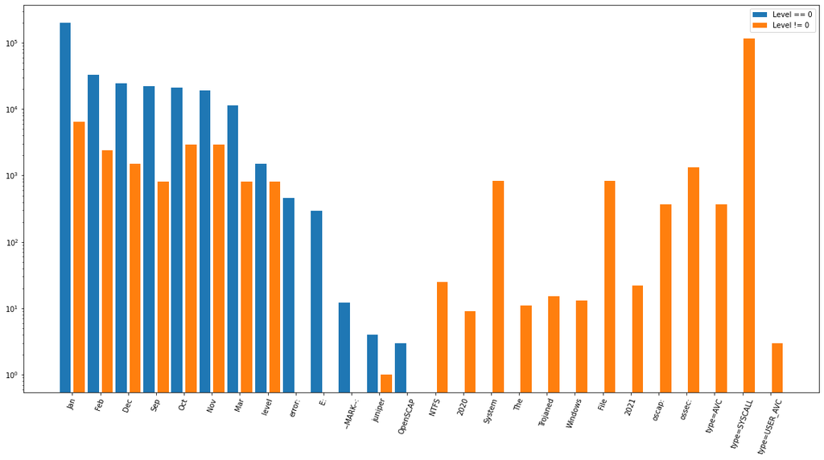

```python
fig, ax = plt.subplots(1,1,figsize = (20,10))
ax.bar([i-0.25 for i in range(full_strings.shape[0])], full_strings.values[:,1], width = 0.4) # lv==0
ax.bar([i+0.25 for i in range(full_strings.shape[0])], full_strings.values[:,0], width = 0.4) # lv != 0

ax.set_yscale("log")
ax.set_xticks(range(full_strings.shape[0]))
ax.set_xticklabels(full_strings.index, rotation = 70)
ax.legend(["Level == 0", "Level != 0"])

fig.show()
```

# check juniper

```python
train_df.loc[train_df.full_log.apply(lambda x : x.split(" ")[0] == 'juniper')]
```

|  | id | level | full_log |
| --- | --- | --- | --- |
| 5144 | 5144 | 0 | juniper |
| 108472 | 108472 | 0 | juniper |
| 170195 | 170195 | 3 | juniper |
| 207811 | 207811 | 0 | juniper |
| 470486 | 470486 | 0 | juniper |

# scipy - countvectorizer

https://wiserloner.tistory.com/917

```python
%%time
train_text = list(train_df['full_log'])
train_level = np.array(train_df['level'])

vectorizer = CountVectorizer(analyzer = "word", max_features = 1000)
train_features = vectorizer.fit_transform(train_text)
```

```
Wall time: 1min 7s
```

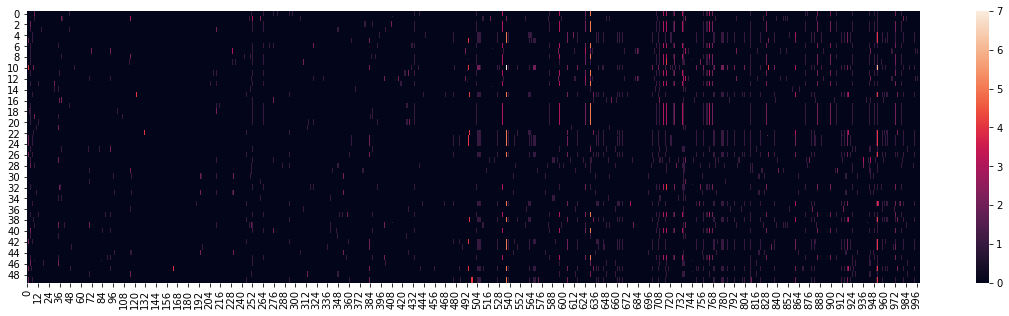

```python
i = train_features[:50].toarray()

fig, ax = plt.subplots(1,1, figsize = (20,5))
sbn.heatmap(i, ax = ax)
fig.show()
```

# character check

```python
chr_set = set() # 중복 허용 안함, 유니크 값만 추출

for x in train_df.itertuples():
    chr_set.update(x.full_log) # set 자료형에 데이터 추가 == update
```

```python
# " ".join( list ) : 리스트에서 문자열으로
" ".join(list(chr_set))
```

```
'o _ 5 ^ w q ȭ “ 런 스 막 들 크 ۿ 8 거 은 렉 무 혔 C V ι 금 ۵ 루 v 워 능 짐 ε G μ 여 m Դ ֽ 룹 K - D ° ð ` { 불 너 깨 b # ؽ y ̹ ȣ + 패 닫 S 쌍 이 / ] c 매 ǻ 램 N 연 도 터 ۾ T մ ã [ 잠 및 Ͻ 간 고 실 값 I = Ȱ ߴ 니 4 의 . 지 2 α 제 한 R 드 9 \n ִ O L } 가 < 석 6   и 수 ˸ 리 h J 는 Z ˾ ʰ ǥ ̰ Ʈ z $ 그 a 오 s 0 ÷ ƺ Ǿ 허 존 페 파 u 린 ; 일 ϵ 보 을 류 Ǵ ؼ 주 ŷ 산 악 …
```

```python
# itertuples() 참고
cnt = 0
for i in train_df.itertuples():
    print(i)
    print(i[1]) # index, id, level, full_log 열 차례로 []로 불러올 수 있음
    print(i.level, i.id)  # itertuples로 바꾼 데이터에 .열이름 하면 그 자료만 볼 수 있음
    cnt += 1
    if cnt == 3:
        break
```

```
Pandas(Index=0, id=0, level=0, full_log='Sep 24 10:02:22 localhost kibana: {"type":"error","@timestamp":"2020-09-24T01:02:22Z","tags":["warning","stats-collection"],"pid":6458,"level":"error","error":{"message":"No Living connections","name":"Error","stack":"Error: No Living connections\\n    at sen…
0
0 0
Pandas(Index=1, id=1, level=0, full_log='Feb  8 16:21:00 localhost logstash: [2021-02-08T16:21:00,548][INFO ][logstash.outputs.elasticsearch] retrying failed action with response code: 503 ({"type"=>"unavailable_shards_exception", "reason"=>"[wazuh-alerts-audit-3.x-2021.16.08][3] primary shard is no…
1
0 1
Pandas(Index=2, id=2, level=0, full_log='Jan 13 01:50:40 localhost kibana: {"type":"error","@timestamp":"2021-01-12T16:50:40Z","tags":["warning","stats-collection"],"pid":4332,"level":"error","error":{"message":"No Living connections","name":"Error","stack":"Error: No Living connections\\n    at sen…
2
0 2
```

```python
# "hello" 의 한 문자열을 넣어도 분해돼서 생성
set("hello")
```

```
{'e', 'h', 'l', 'o'}
```

# vocabulary

일반적으로 자연어 처리에서는 character 나 word 패턴들을 미리 분해하여 vocabulary 로 저장해둡니다.  
CountVectorizer 는 기본적으로 word 단위로 작동하며 character 단위로도 작동 가능합니다.  
이때 반드시 필요한 것이 vocabulary 인데요.  
CountVectorizer 를 학습시킨 후, CountVectorizer.vocabulary_ 를 활용하면 vocab을 확일 할 수 있습니다.

```python
# CountVectorizer 학습시킨 후 vocabulary 확인  -- max_feature = 1000으로 만들어서 1000개만
len(vectorizer.vocabulary_)
```

```
1000
```

```python
vectorizer=CountVectorizer(analyzer="word", max_features=10000)
train_features=vectorizer.fit_transform(train_text)
vocab = vectorizer.vocabulary_
```

vocab을 크게하면 다양한 단어를 전부 처리할 수 있게 되지만 의미없는 나열들이 포함될 가능성이 존재합니다.  
이번 대회에서는 숫자의 반복이 의미를 가질 수 있지만 어쩌면 아무런 의미가 없을 수도 있습니다.  
각 log 마다 vocab의 word 중에 숫자들이 들어간 갯수를 세어보고, vocab에서 숫자들이 어떤 비율을 차지하는지 확인해보겠습니다.

```python
vocab_list = list(vocab.keys())
```

```python
pd.Series(vocab_list).apply(lambda x: len(re.sub(r'[^0-9]', '', x))).unique()
```

```
array([  0,   2,   4,   3,   1,  10,   6,   5,   8,   7,  15,  16,  26,
         9,  57,  64,  11,  81,  13, 172,  20,  56,  63,  55,  51,  24,
        62,  68,  28,  60, 181,  48, 129, 222,  34,  22,  53,  17,  14,
        35,  19,  30, 116,  18, 227, 101, 122,  58,  65, 118, 171,  25,
        12, 120,  52, 128, 218, 215,  27,  54, 345,  31, 157,  37,  92,
       214,  59, 212], dtype=int64)
```

```python
# re 에서 ^ 의 차이 참고
print(re.sub(r'[^0-9]', '', "kdafn0kdn345lkf88"))
print(re.sub(r'[0-9]', '', "kdafn0kdn345lkf88"))
```

```
034588
kdafnkdnlkf
```

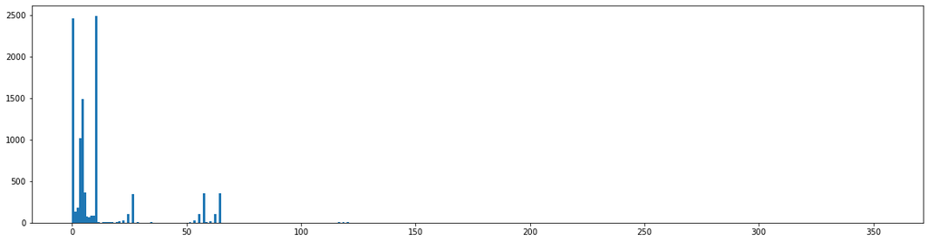

```python
fig, ax = plt.subplots(1,1,figsize = (20,5))

ax.hist(pd.Series(vocab_list).apply(lambda x: len(re.sub(r'[^0-9]', '', x))), bins = [i for i in range(0,355,1)])
fig.show()
```

다양한 숫자의 조합이 많은 비중 차지.  
숫자가 아예 존재하지 않는 vocab 은 2500여건,  
그외의 7500여건은 숫자 포함,  
그중 1천여건은 20개 이상의 숫자로 구성되어 있음.  
따라서, 숫자를 으로 토큰화 하는 방법은 vocab을 효과적으로 작성하는 좋은 해결책일 수 있음.

# make vocabulary

```python
tt= train_df.full_log.copy()
type(tt) # series
```

```
pandas.core.series.Series
```

```python
# 줄바꿈 제거 \n
tt = tt.apply(lambda x: re.sub(r'\\n', " ", x))
```

```python
tt[0]
```

```
'Sep 24 10:02:22 localhost kibana: {"type":"error","@timestamp":"2020-09-24T01:02:22Z","tags":["warning","stats-collection"],"pid":6458,"level":"error","error":{"message":"No Living connections","name":"Error","stack":"Error: No Living connections     at sendReqWithConnection (/usr/share/kibana/node…
```

```python
# 일부 특수 문자를 제외하고 전부 제거
tt = tt.apply(lambda x: re.sub(r'[^a-zA-Zㄱ-ㅣ가-힣0-9:=\ㄴ\(\)./,\<\>]+', '', x))
```

```python
tt[0]
```

```
'Sep2410:02:22localhostkibana:type:error,timestamp:20200924T01:02:22Z,tags:warning,statscollection,pid:6458,level:error,error:message:NoLivingconnections,name:Error,stack:Error:NoLivingconnectionsatsendReqWithConnection(/usr/share/kibana/nodemodules/elasticsearch/src/lib/transport.js:226:15)atnext(/…
```

```python
# 일부 특수문자 전후 공백 추가
tt = tt.apply(lambda x: re.sub(r' ?(?P<note>[:=\(\)./,\<\>]) ?','\g<note> ', x))
```

```python
tt[0]
```

```
'Sep2410: 02: 22localhostkibana: type: error, timestamp: 20200924T01: 02: 22Z, tags: warning, statscollection, pid: 6458, level: error, error: message: NoLivingconnections, name: Error, stack: Error: NoLivingconnectionsatsendReqWithConnection( / usr/ share/ kibana/ nodemodules/ elasticsearch/ src/ l…
```

```python
# 숫자 마스킹
tt = tt.apply(lambda x: re.sub(r'[0-9]+','<num>', x)) # 숫자가 몇개가 연속으로 있든 하나로 보고 <num>처리
```

```python
tt[0]
```

```
'Sep<num>: <num>: <num>localhostkibana: type: error, timestamp: <num>T<num>: <num>: <num>Z, tags: warning, statscollection, pid: <num>, level: error, error: message: NoLivingconnections, name: Error, stack: Error: NoLivingconnectionsatsendReqWithConnection( / usr/ share/ kibana/ nodemodules/ elastic…
```

```python
# 공백제거
tt = tt.apply(lambda x: re.sub(r'\s+', ' ', x))
```

```python
tt[0]
```

```
'Sep<num>: <num>: <num>localhostkibana: type: error, timestamp: <num>T<num>: <num>: <num>Z, tags: warning, statscollection, pid: <num>, level: error, error: message: NoLivingconnections, name: Error, stack: Error: NoLivingconnectionsatsendReqWithConnection( / usr/ share/ kibana/ nodemodules/ elastic…
```

```python
# 필터링된 log 들로 character 확인
chr_set = set()

for i in tt.iteritems():
    chr_set.update(i[1])

' '.join(list(chr_set))
```

```
'o w q 런 스 막 들 크 거 은 렉 무 혔 C V 금 루 v 워 능 짐 G 여 m 룹 K D 너 불 깨 b y 패 닫 S 쌍 이 / 매 c 램 N 연 도 터 T 잠 및 간 고 실 값 I = 니 의 . 지 제 한 R 드 O L 가 < 석   수 리 h J 는 Z z 그 a 오 s 허 존 페 파 u 린 일 보 류 을 주 악 있 e 더 많 료 부 객 합 줄 아 었 i r 서 로 중 시 요 n 기 > 프 비 x 음 A 웹 킹 구 t P 결 B p Y U 닙 없 습 l 청 다 M k ) F 어 j : 산 경 갈 인 넘 성 Q 탐 d 됨…
```

```python
# 참고 : 시리즈르르 iteritems() 없이 그대로 출력하면 값만 나옴, 인덱스도 같이 필요할 땐 iteritems() 필요
cnt = 0
for i in tt:
    print(i)
    cnt += 1
    if cnt == 3:
        break
```

```
Sep<num>: <num>: <num>localhostkibana: type: error, timestamp: <num>T<num>: <num>: <num>Z, tags: warning, statscollection, pid: <num>, level: error, error: message: NoLivingconnections, name: Error, stack: Error: NoLivingconnectionsatsendReqWithConnection( / usr/ share/ kibana/ nodemodules/ elastics…
Feb<num>: <num>: <num>localhostlogstash: <num>T<num>: <num>: <num>, <num>INFOlogstash. outputs. elasticsearchretryingfailedactionwithresponsecode: <num>( type= > unavailableshardsexception, reason= > wazuhalertsaudit<num>. x<num>. <num>. <num>primaryshardisnotactiveTimeout: <num>m, request: BulkShar…
Jan<num>: <num>: <num>localhostkibana: type: error, timestamp: <num>T<num>: <num>: <num>Z, tags: warning, statscollection, pid: <num>, level: error, error: message: NoLivingconnections, name: Error, stack: Error: NoLivingconnectionsatsendReqWithConnection( / usr/ share/ kibana/ nodemodules/ elastics…
```

## 단어 추출

```python
word_set = set()

for x in tt.iteritems():
    word_set.update(x[1].split(" "))

len(word_set)
```

```
46335
```

```python
# 참고 : set 에 입력하는 방식에 따른 차이
d=set(["sd","fg","fdg"])
print(d)

h = set("hello")
print(h)
```

```
{'fg', 'sd', 'fdg'}
{'h', 'o', 'e', 'l'}
```

## 한글 단어 체크

```python
' '.join(re.findall(r'[ㄱ-ㅣ가-힣]+', ' '.join(list(word_set))))
```

```
'줄은키값쌍도아니고 그룹도아니고 전산및비전산자료보존요청서 파일을여는중오류 구매오더 파이프가깨어짐 악성코드 네트워크가접근불가능합니다 경로 시간제한을넘었습니다 연결이닫혔습니다 그런파일이나디렉터리가없습니다 열린파일이너무많음 허가거부 의객체에 시간제한을넘었습니다 키파일에들어있는 연결이거부됨 주석도아닙니다 파일 열기실패 프로그램이잠금을막았습니다 호스트로갈루트가없음 악성메일의심 인터페이스가없습니다 웹해킹의심탐지 잠글수없습니다'
```

문제는 마스킹된 숫자들 사이에 갇힌 영어들입니다.  
숫자와 마찬가지로 숫자사이에 고립된 영어들은 큰 의미를 갖지 못할수 있습니다.  
숫자들과 섞인 영어들은 eng 토큰화 시키겠습니다.

```python
tt[0]
```

```
'Sep<num>: <num>: <num>localhostkibana: type: error, timestamp: <num>T<num>: <num>: <num>Z, tags: warning, statscollection, pid: <num>, level: error, error: message: NoLivingconnections, name: Error, stack: Error: NoLivingconnectionsatsendReqWithConnection( / usr/ share/ kibana/ nodemodules/ elastic…
```

```python
tt2 = tt.apply(lambda x: re.sub(r'\>[a-zA-Z]+\<', '><eng><', x))
tt2[0]
```

```
'Sep<num>: <num>: <num>localhostkibana: type: error, timestamp: <num><eng><num>: <num>: <num>Z, tags: warning, statscollection, pid: <num>, level: error, error: message: NoLivingconnections, name: Error, stack: Error: NoLivingconnectionsatsendReqWithConnection( / usr/ share/ kibana/ nodemodules/ ela…
```

```python
tt2 = tt2.apply(lambda x: re.sub(r'[a-zA-Z]+\<', '<eng><', x))
tt2 = tt2.apply(lambda x: re.sub(r'\>[a-zA-Z]+', '><eng>', x))
```

```python
word_set = set()
for i in tt2.iteritems():
    word_set.update(i[1].split(" "))

len(word_set)
```

```
11068
```

단어의 수가 11068로 줄어듬.  
영어 단어 중 의미없는 단어가 있을 수 있으며 해결책으로 sentencepiece등을 사용해볼 수 있습니다.

```python
import pickle
# tt2 : train_df 의 full_log 를 전처리한 것
# word_set : train_df 의 full_log 를 전처리한 후 word 로 set()에 넣은 것
# vocab : countvecterizer 의 max_features = 10000으로 설정한 것의 vocab

word_set.remove('')
vocab = {i : n for n,i in enumerate(word_set)}

with open(os.path.join('data','vocab.pkl'), wb) as f:
    pickle.dump(vocab, f)
```

```python
# train_df 의 full_log 를 전처리한 데이터로 대체
train_df.full_log = tt2
```

```python
train_df.to_csv(os.path.join('data', 'train_vocab.csv'), index = False)
```

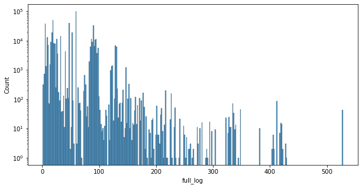

```python
fig, ax = plt.subplots(1,1, figsize = (10,5))
sbn.histplot(train_df.iloc[:, -1].apply(lambda x: len(x.split(" "))), ax=ax)
ax.set_yscale("log")
fig.show()
```

```python
train_df.iloc[:,-1].apply(lambda x: len(x.split(' '))<250).mean()*100
```

```
99.88625119457389
```